# Tugas-Pertemuan-7

Elardian Putera Ramadhan (G1401231042)

2025-10-09

## **1. Persiapan dan Pemisahan Data (Train & Test)**

Langkah pertama adalah menyiapkan data deret waktu Anda dan membaginya menjadi 80% data *training* dan 20% data *testing*.

```r
# Menggunakan library yang relevan
library(forecast)
library(tseries)
```

```r
library(ggplot2)
library(TSA) # Library tambahan untuk EACF
library(lmtest) # Library tambahan untuk coeftest
data <- read.csv("C:/Users/Putera Ramadhan/OneDrive/Documents/IPB University/Semester 5/(MPDW) Metode Peramalan Deret Waktu/UTS/Praktikum/MPDW/Pertemuan 1/Data/Reversed Bitcoin Historical Price.csv")
data$Date <- as.Date(data$Date, format="%m/%d/%Y")
data$Price <- as.numeric(gsub(",", "", data$Price))
data_subset <- data[253:378, ]

# Membuat objek time series (ts) dari kolom Price
# Frekuensi 52 untuk data mingguan.
# Kita tentukan start date dari data_subset$Date[1] yaitu "2020-11-01" (minggu ke-44 tahun 2020)
harga_ts <- ts(data_subset$Price, start = c(2020, 44), frequency = 52)

# Menghitung titik pembagian data
split_point <- floor(0.8 * length(harga_ts))

# Memisahkan data train dan test
train_data <- window(harga_ts, end = time(harga_ts)[split_point])
test_data <- window(harga_ts, start = time(harga_ts)[split_point + 1])

# Menampilkan panjang data masing-masing
cat("Panjang Data Asli   :", length(harga_ts), "\n")
```

```
## Panjang Data Asli   : 126
```

```r
cat("Panjang Data Train  :", length(train_data), "\n")
```

```
## Panjang Data Train  : 100
```

```r
cat("Panjang Data Test   :", length(test_data), "\n")
```

```
## Panjang Data Test   : 26
```

## **2. Pengecekan Kestasioneran dalam Rataan (Mean) pada Data Train**

Kita akan menggunakan dua metode: visualisasi (plot deret waktu dan ACF) dan uji statistik formal (Augmented Dickey-Fuller Test).

### **a. Analisis Visual**

**Plot Deret Waktu:**

Plot data train untuk melihat apakah ada tren (pola naik atau turun) yang jelas.

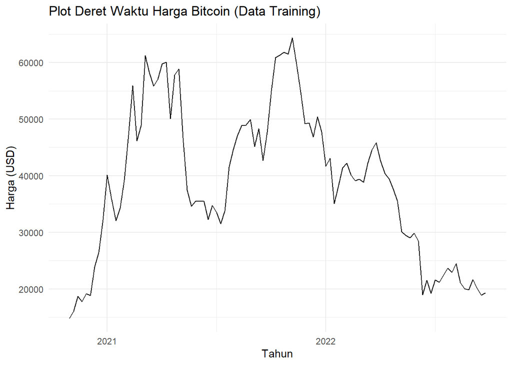

```r
autoplot(train_data, main = "Plot Deret Waktu Harga Bitcoin (Data Training)",
         xlab="Tahun", ylab="Harga (USD)") +
  theme_minimal()
```

**Interpretasi:** Plot tersebut menunjukkan data yang **tidak stasioner** karena adanya **pola tren naik-turun yang sangat jelas**, yang berarti nilai rata-rata data tidak konstan melainkan terus berubah seiring waktu.

**Plot ACF (Autocorrelation Function):**

Plot ACF menunjukkan korelasi antara observasi saat ini dengan observasi sebelumnya (lag).

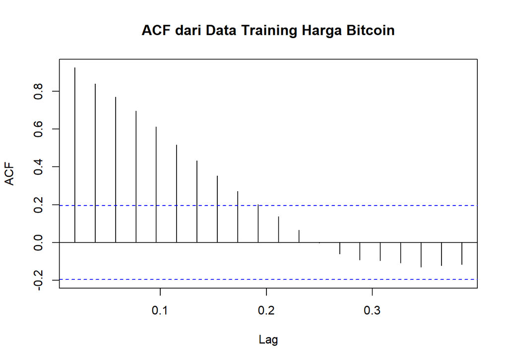

```r
acf(train_data, main = "ACF dari Data Training Harga Bitcoin")
```

**Interpretasi:** Plot ACF menunjukkan **penurunan yang sangat lambat (slow decay)**. Korelasi pada lag-lag awal sangat tinggi dan turun secara linear. Ini adalah ciri khas dari data yang memiliki tren atau **tidak stasioner dalam rataan**.

### **b. Uji Statistik (Augmented Dickey-Fuller Test)**

Uji ADF digunakan untuk menguji hipotesis adanya *unit root*.

- $H_0$: Data tidak stasioner (memiliki *unit root*).
- $H_1$: Data stasioner.

Kita menolak $H_0$ jika **p-value < 0.05**.

```r
adf.test(train_data)
```

```
##
##  Augmented Dickey-Fuller Test
##
## data:  train_data
## Dickey-Fuller = -2.7008, Lag order = 4, p-value = 0.2863
## alternative hypothesis: stationary
```

**Interpretasi:** Didapatkan **p-value = 0.2863**, yang jauh lebih besar dari 0.05. Artinya, kita **gagal menolak** $H_0$. Ini secara statistik mengonfirmasi bahwa data *training* **tidak stasioner dalam rataan**.

## **3. Penanganan Ketidakstasioneran dalam Rataan**

Untuk mengatasi tren, kita akan melakukan **differencing** orde 1 pada data *training*.

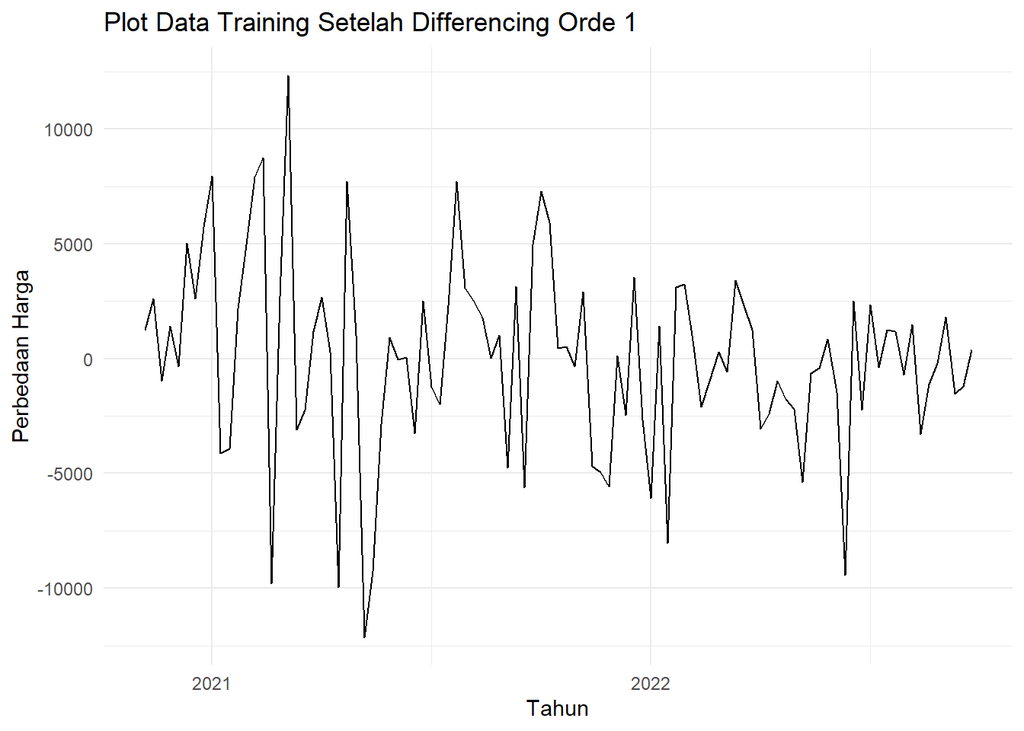

```r
# Melakukan differencing orde 1
train_data_diff1 <- diff(train_data, differences = 1)

# Plot data setelah differencing
autoplot(train_data_diff1, main = "Plot Data Training Setelah Differencing Orde 1",
         xlab="Tahun", ylab="Perbedaan Harga") +
  theme_minimal()
```

### **Verifikasi Ulang Kestasioneran Rataan**

Sekarang, kita uji kembali data yang sudah di-*differencing*.

- **Plot ACF:**

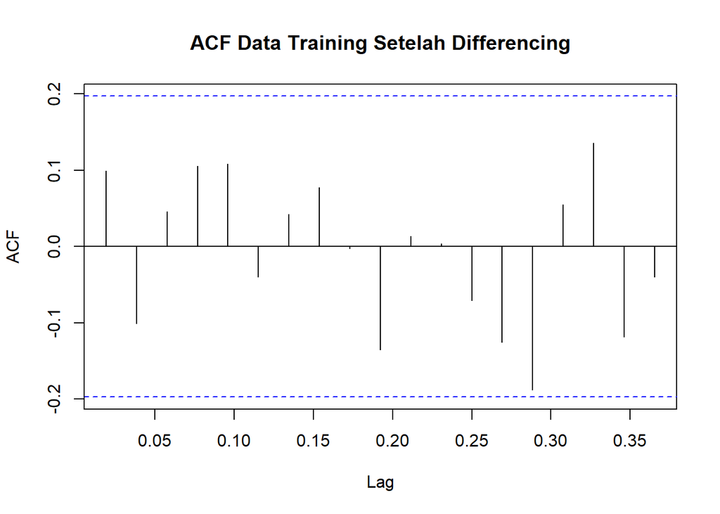

  ```r
  acf(train_data_diff1, main = "ACF Data Training Setelah Differencing")
  ```

  **Interpretasi:** Plot ACF sekarang menunjukkan penurunan yang cepat (cut off) setelah lag 0. Ini menandakan data sudah stasioner dalam rataan.
- **Uji ADF:**

  ```r
  adf.test(train_data_diff1)
  ```

  ```
  ##
  ##  Augmented Dickey-Fuller Test
  ##
  ## data:  train_data_diff1
  ## Dickey-Fuller = -3.7744, Lag order = 4, p-value = 0.023
  ## alternative hypothesis: stationary
  ```

  **Interpretasi:** **p-value = 0.023** (atau bisa lebih kecil tergantung *lag order*), yang sekarang lebih kecil dari 0.05. Kita **berhasil menolak** $H_0$.

**Kesimpulan:** Data `train_data_diff1` sekarang sudah **stasioner dalam rataan**.

## **4. Pengecekan Kestasioneran dalam Ragam (Variance)**

Sekarang kita periksa apakah ragam dari data yang sudah stasioner rataan (`train_data_diff1`) bersifat konstan.

### **a. Analisis Visual**

Lihat kembali plot data setelah di-*differencing*. Perhatikan apakah lebar fluktuasi data sama sepanjang waktu.

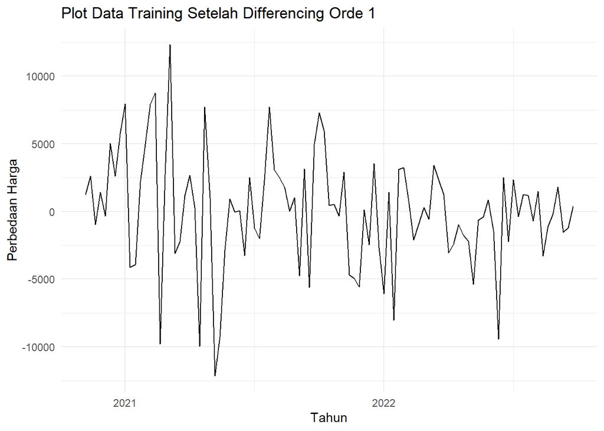

```r
autoplot(train_data_diff1, main = "Plot Data Training Setelah Differencing Orde 1",
         xlab="Tahun", ylab="Perbedaan Harga") +
  theme_minimal()
```

**Interpretasi:** Secara visual, terlihat bahwa fluktuasi (volatilitas) harga di beberapa bagian tampak lebih besar dibandingkan bagian lainnya. Ini mengindikasikan kemungkinan adanya **ketidakstasioneran dalam ragam**.

### **b. Uji Statistik (Box-Cox Plot)**

Transformasi Box-Cox membantu menstabilkan ragam. Untuk menemukan parameter transformasi ($\lambda$) yang paling sesuai, kita bisa memvisualisasikannya dengan plot Box-Cox yang menunjukkan nilai *Log-Likelihood* untuk berbagai kandidat $\lambda$. Nilai $\lambda$ yang optimal adalah yang memberikan nilai *Log-Likelihood* tertinggi.

```r
# Memanggil library tambahan untuk plot Box-Cox
library(MASS)
train_data_positive <- train_data_diff1 + abs(min(train_data_diff1)) + 1
```

**Plot Box-Cox untuk Menentukan Lambda**

Plot di bawah ini akan menunjukkan nilai Log-Likelihood pada sumbu Y untuk rentang nilai λ pada sumbu X. Puncak dari kurva ini adalah nilai λ optimal.

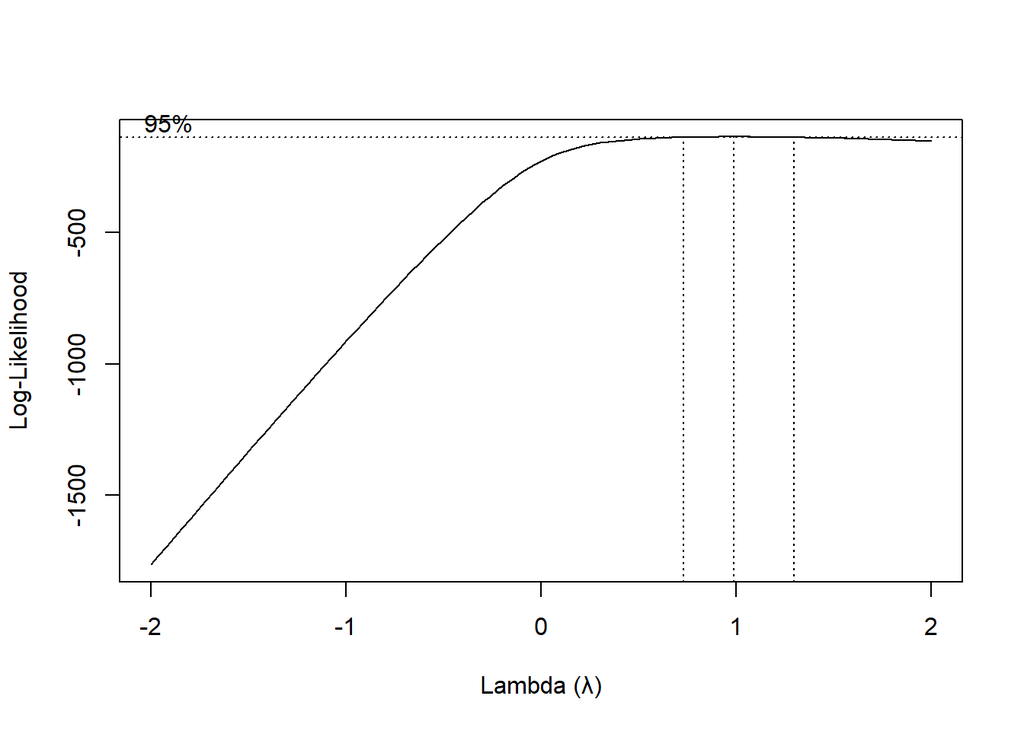

```r
# Membuat Plot Box-Cox
boxcox(train_data_positive ~ 1,
       xlab="Lambda (λ)",
       ylab="Log-Likelihood")
```

**Lambda Optimum dan Selang Kepercayaan 95%**

Sekarang akan dihitung nilai pastinya menggunakan fungsi `BoxCox.lambda()` dari paket `forecast`, sekaligus mencari selang kepercayaan 95% untuk nilai lambda tersebut. Selang kepercayaan ini memberi kita rentang nilai $\lambda$ yang paling mungkin.

```r
# Mencari lambda optimal menggunakan paket forecast (lebih praktis)
lambda_opt <- BoxCox.lambda(train_data_positive)
cat("Nilai Lambda Optimal:", lambda_opt, "\n")
```

```
## Nilai Lambda Optimal: 1
```

```r
# Untuk mencari selang kepercayaan, kita bisa menggunakan kembali hasil dari fungsi boxcox()
bc <- boxcox(train_data_positive ~ 1, plotit = FALSE) # Menjalankan tanpa membuat plot lagi
lambda_ci <- data.frame(lambda = bc$x, loglik = bc$y)

# Menentukan batas bawah dan atas untuk selang kepercayaan 95%
ci_boundary <- max(lambda_ci$loglik) - 0.5 * qchisq(0.95, 1)
ci_lower <- min(lambda_ci$lambda[lambda_ci$loglik >= ci_boundary])
ci_upper <- max(lambda_ci$lambda[lambda_ci$loglik >= ci_boundary])

cat("Selang Kepercayaan 95% untuk Lambda: (", round(ci_lower, 2), ",", round(ci_upper, 2), ")\n")
```

```
## Selang Kepercayaan 95% untuk Lambda: ( 0.8 , 1.2 )
```

## **5. Identifikasi Model ARIMA Tentatif**

Setelah data stasioner (`train_data_diff1`), langkah selanjutnya adalah mengidentifikasi orde AR (p) dan MA (q) yang potensial. Kita akan menggunakan plot ACF, PACF, dan EACF dari data yang sudah stasioner ini.

### **a. Plot ACF (Autocorrelation Function)**

Plot ACF membantu kita mengidentifikasi orde **MA (q)**. Pola *cut-off* (turun drastis ke nol) pada lag ke-q menunjukkan model MA(q).

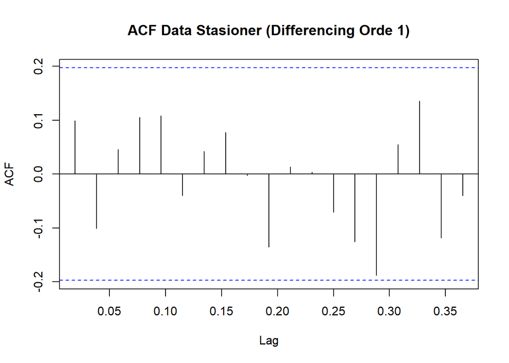

```r
acf(train_data_diff1, main="ACF Data Stasioner (Differencing Orde 1)")
```

**Interpretasi:** Plot ACF tidak menunjukkan adanya lag yang signifikan. Hal ini berarti model tidak memerlukan komponen *Moving Average* (MA), sehingga orde q dapat diasumsikan sebagai 0.

### **b. Plot PACF (Partial Autocorrelation Function)**

Plot PACF membantu kita mengidentifikasi orde **AR (p)**. Pola *cut-off* pada lag ke-p menunjukkan model AR(p).

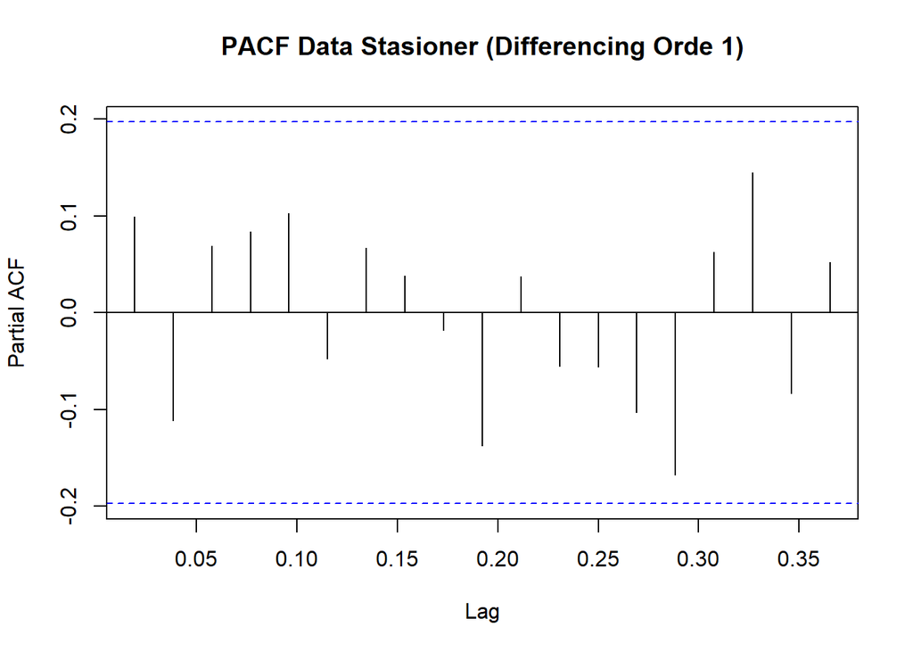

```r
pacf(train_data_diff1, main="PACF Data Stasioner (Differencing Orde 1)")
```

**Interpretasi:** Plot PACF tidak menunjukkan adanya lag yang signifikan. Ini berarti model tidak memerlukan komponen *AutoRegressive* (AR), sehingga **orde p dapat diasumsikan sebagai 0**.

### **c. Plot EACF (Extended Autocorrelation Function)**

EACF adalah alat yang lebih canggih untuk mengidentifikasi model ARMA campuran. Kita mencari sudut kanan atas dari segitiga nol (“O”) pada tabel EACF.

```r
eacf(train_data_diff1)
```

```
## AR/MA
##   0 1 2 3 4 5 6 7 8 9 10 11 12 13
## 0 o o o o o o o o o o o  o  o  o
## 1 x o o o o o o o o o o  o  o  o
## 2 x o o o o o o o o o o  o  o  o
## 3 x o x o o o o o o o o  o  o  o
## 4 x o x x o o o o o o o  o  o  o
## 5 x o x o x o o o o o o  o  o  o
## 6 x x x o x x o o o o o  o  o  o
## 7 x x o o x x o o o o o  o  o  o
```

**Interpretasi:**  
Tabel EACF menyarankan beberapa model kandidat. Puncak segitiga nol (“o”) berada pada:

- **AR=0, MA=0**: Ini menunjukkan model **ARIMA(0,1,0)**.
- **AR=1, MA=1**: Ini menunjukkan model **ARIMA(1,1,1)**.
- **AR=2, MA=1**: Ini menunjukkan model **ARIMA(2,1,1)**.

**Kesimpulan Identifikasi:**  
Berdasarkan ketiga plot (ACF, PACF, dan EACF), model tentatif yang paling potensial adalah:

1. **ARIMA(0,1,0)**: Dari EACF (saran utama), ACF, dan PACF.
2. **ARIMA(1,1,1)**: Model campuran yang disarankan oleh EACF.
3. **ARIMA(1,1,0)**: Dari pertimbangan plot PACF (model AR murni).
4. **ARIMA(0,1,1)**: Dari pertimbangan plot ACF (model MA murni).
5. **ARIMA(2,1,1)**: Model campuran lain yang disarankan oleh EACF.

## **6. Pendugaan Parameter Model Tentatif**

Sekarang kita akan menduga parameter untuk setiap model tentatif yang telah diidentifikasi menggunakan data `train_data`.

### **a. Model ARIMA(0,1,0)**

Model ini adalah random walk dan tidak memiliki parameter AR atau MA untuk diestimasi, sehingga uji koefisien tidak diperlukan.

```r
model1 <- Arima(train_data, order=c(0,1,0))
summary(model1)
```

```
## Series: train_data
## ARIMA(0,1,0)
##
## sigma^2 = 17711007:  log likelihood = -966.61
## AIC=1935.23   AICc=1935.27   BIC=1937.82
##
## Training set error measures:
##                    ME    RMSE      MAE        MPE     MAPE      MASE       ACF1
## Training set 44.98328 4187.35 3092.297 -0.3161549 8.198232 0.1696936 0.09935743
```

### **b. Model ARIMA(1,1,1)**

```r
model2 <- Arima(train_data, order=c(1,1,1))
summary(model2)
```

```
## Series: train_data
## ARIMA(1,1,1)
##
## Coefficients:
##           ar1     ma1
##       -0.7713  0.8826
## s.e.   0.1629  0.1181
##
## sigma^2 = 17515878:  log likelihood = -965.12
## AIC=1936.24   AICc=1936.49   BIC=1944.03
##
## Training set error measures:
##                    ME     RMSE      MAE      MPE     MAPE      MASE       ACF1
## Training set 41.88648 4121.941 3100.058 -0.28686 8.217482 0.1701194 0.01413191
```

```r
coeftest(model2)
```

```
##
## z test of coefficients:
##
##     Estimate Std. Error z value  Pr(>|z|)
## ar1 -0.77128    0.16288 -4.7351 2.189e-06 ***
## ma1  0.88257    0.11805  7.4761 7.654e-14 ***
## ---
## Signif. codes:  0 '***' 0.001 '**' 0.01 '*' 0.05 '.' 0.1 ' ' 1
```

**Interpretasi:** Hasil uji menunjukkan bahwa parameter `ar1` dan `ma1` **keduanya sangat signifikan** secara statistik.

Nilai *p-value* (`Pr(>|z|)`) untuk kedua koefisien tersebut jauh lebih kecil dari 0.05. Ini mengonfirmasi bahwa model **ARIMA(1,1,1)** adalah kandidat yang kuat, karena baik komponen *AutoRegressive* maupun *Moving Average*-nya memberikan kontribusi yang berarti.

### **c. Model ARIMA(1,1,0)**

```r
model3 <- Arima(train_data, order=c(1,1,0))
summary(model3)
```

```
## Series: train_data
## ARIMA(1,1,0)
##
## Coefficients:
##          ar1
##       0.0985
## s.e.  0.0995
##
## sigma^2 = 17714653:  log likelihood = -966.13
## AIC=1936.25   AICc=1936.38   BIC=1941.45
##
## Training set error measures:
##                    ME     RMSE      MAE        MPE     MAPE      MASE
## Training set 40.88571 4166.577 3084.192 -0.2751593 8.210345 0.1692488
##                    ACF1
## Training set 0.01180844
```

```r
coeftest(model3)
```

```
##
## z test of coefficients:
##
##     Estimate Std. Error z value Pr(>|z|)
## ar1 0.098542   0.099532  0.9901   0.3221
```

**Interpretasi:** Hasil uji menunjukkan bahwa parameter `ar1` **tidak signifikan** secara statistik.

Nilai *p-value*nya (**0.3221**) jauh lebih besar dari tingkat signifikansi 0.05. Ini berarti komponen *AutoRegressive* (AR) tidak memberikan kontribusi yang berarti pada model, sehingga **ARIMA(1,1,0)** kemungkinan bukan model yang baik untuk data ini.

### **d. Model ARIMA(0,1,1)**

```r
model4 <- Arima(train_data, order=c(0,1,1))
summary(model4)
```

```
## Series: train_data
## ARIMA(0,1,1)
##
## Coefficients:
##          ma1
##       0.1268
## s.e.  0.1124
##
## sigma^2 = 17664101:  log likelihood = -965.99
## AIC=1935.98   AICc=1936.1   BIC=1941.17
##
## Training set error measures:
##                    ME     RMSE     MAE        MPE     MAPE      MASE
## Training set 40.43156 4160.627 3086.75 -0.2691044 8.233222 0.1693892
##                     ACF1
## Training set -0.01269696
```

```r
coeftest(model4)
```

```
##
## z test of coefficients:
##
##     Estimate Std. Error z value Pr(>|z|)
## ma1  0.12680    0.11238  1.1284   0.2592
```

**Interpretasi:** Hasil uji menunjukkan bahwa parameter `ma1` **tidak signifikan** secara statistik.

Nilai *p-value*nya (**0.2592**) jauh lebih besar dari tingkat signifikansi 0.05. Ini berarti komponen *Moving Average* (MA) tidak memberikan kontribusi yang berarti, sehingga **ARIMA(0,1,1)** kemungkinan bukan model yang baik untuk data ini.

### **e. Model ARIMA(2,1,1)**

```r
model5 <- Arima(train_data, order=c(2,1,1))
summary(model5)
```

```
## Series: train_data
## ARIMA(2,1,1)
##
## Coefficients:
##           ar1     ar2     ma1
##       -0.7671  0.0198  0.8913
## s.e.   0.1514  0.1084  0.1138
##
## sigma^2 = 17692981:  log likelihood = -965.1
## AIC=1938.21   AICc=1938.63   BIC=1948.59
##
## Training set error measures:
##                    ME     RMSE      MAE        MPE     MAPE      MASE
## Training set 41.31456 4121.318 3097.423 -0.2792203 8.209322 0.1699748
##                     ACF1
## Training set 0.002183327
```

```r
coeftest(model5)
```

```
##
## z test of coefficients:
##
##      Estimate Std. Error z value  Pr(>|z|)
## ar1 -0.767104   0.151352 -5.0683 4.013e-07 ***
## ar2  0.019807   0.108388  0.1827     0.855
## ma1  0.891320   0.113805  7.8320 4.803e-15 ***
## ---
## Signif. codes:  0 '***' 0.001 '**' 0.01 '*' 0.05 '.' 0.1 ' ' 1
```

**Intepretasi:** Hasil uji menunjukkan hasil yang **campuran**, di mana tidak semua parameter signifikan.

- **Signifikan** Parameter `ar1` dan `ma1` **sangat signifikan** secara statistik, dengan nilai *p-value* yang jauh lebih kecil dari 0.05.
- **Tidak Signifikan** Parameter `ar2` **tidak signifikan**, karena *p-value*nya (**0.855**) sangat besar.

**Kesimpulan**

Karena parameter `ar2` tidak signifikan, model **ARIMA(2,1,1)** ini kemungkinan besar *overfit* (terlalu kompleks). Menambahkan komponen AR orde kedua tidak memberikan kontribusi yang berarti. Model yang lebih sederhana tanpa `ar2`, yaitu **ARIMA(1,1,1)**, adalah pilihan yang lebih baik.

## **7. Ringkasan Kriteria Informasi (AICc & BIC)**

Kita akan membandingkan nilai AICc dan BIC dari kelima model. Keduanya adalah kriteria seleksi model di mana nilai **terkecil** menunjukkan model yang paling baik (parsimonious). BIC cenderung memberikan penalti yang lebih besar untuk model yang kompleks.

```r
# Membuat vektor nama model, nilai AICc, dan nilai BIC
model_names <- c("ARIMA(0,1,0)", "ARIMA(1,1,1)", "ARIMA(1,1,0)", "ARIMA(0,1,1)", "ARIMA(2,1,1)")
aicc_values <- c(model1$aicc, model2$aicc, model3$aicc, model4$aicc, model5$aicc)
bic_values <- c(BIC(model1), BIC(model2), BIC(model3), BIC(model4), BIC(model5))

# Membuat data frame
summary_table <- data.frame(
  Model = model_names,
  AICc = aicc_values,
  BIC = bic_values
)

# Mengurutkan data frame berdasarkan nilai AICc (bisa juga berdasarkan BIC)
summary_table_sorted <- summary_table[order(summary_table$AICc), ]

# Menampilkan tabel ringkasan
print(summary_table_sorted)
```

```
##          Model     AICc      BIC
## 1 ARIMA(0,1,0) 1935.271 1937.825
## 4 ARIMA(0,1,1) 1936.103 1941.169
## 3 ARIMA(1,1,0) 1936.380 1941.445
## 2 ARIMA(1,1,1) 1936.495 1944.027
## 5 ARIMA(2,1,1) 1938.635 1948.589
```

**Interpretasi Tabel:**

Berdasarkan tabel, model **ARIMA(0,1,0)** adalah yang terbaik karena memiliki nilai AICc dan BIC terendah.

Meskipun parameter pada model ARIMA(1,1,1) signifikan, kriteria informasi (AICc/BIC) menunjukkan bahwa kompleksitas tambahan tersebut tidak memberikan peningkatan performa yang cukup.

**Rekomendasi:** Lanjutkan analisis sisaan pada kedua model—**ARIMA(0,1,0)** dan **ARIMA(1,1,1)**—untuk membuat keputusan akhir.

## **8. Analisis Sisaan (Uji Diagnostik Formal)**

Pada tahap ini, kita akan melakukan uji diagnostik formal pada sisaan dari kedua model kandidat, **ARIMA(0,1,0)** dan **ARIMA(1,1,1)**, untuk memastikan sisaan tersebut memenuhi asumsi *white noise*.

### **a. Analisis Sisaan Model ARIMA(0,1,0)**

Model ini merupakan kandidat terbaik berdasarkan kriteria AICc dan BIC.

**Eksplorasi Visual**

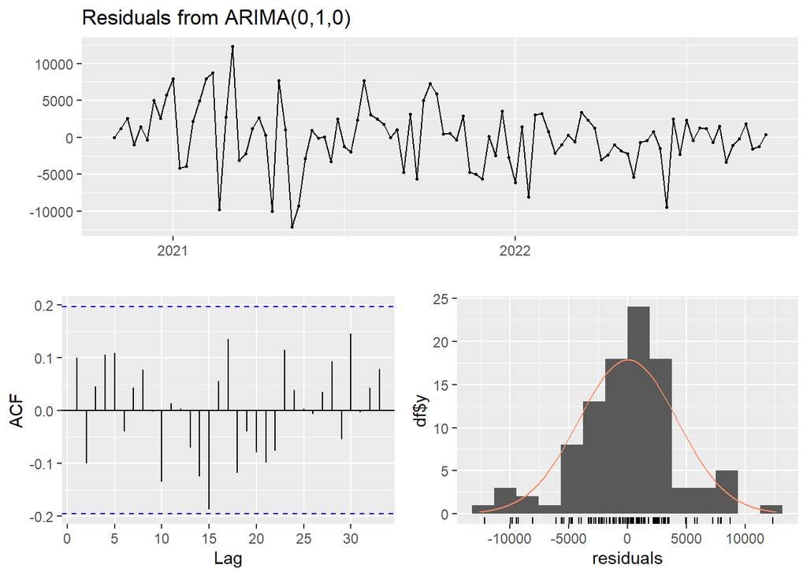

```
##
##  Ljung-Box test
##
## data:  Residuals from ARIMA(0,1,0)
## Q* = 19.901, df = 20, p-value = 0.4641
##
## Model df: 0.   Total lags used: 20
```

```r
# Analisis visual untuk ARIMA(0,1,0)
checkresiduals(model1)
```

**Interpretasi Visual:**

1. **Plot Sisaan vs Waktu:** Sisaan tampak tersebar acak di sekitar nol tanpa adanya pola tren atau siklus yang jelas. Ini pertanda baik.
2. **Plot ACF Sisaan:** Tidak ada lag yang signifikan secara statistik (tidak ada garis yang melebihi batas biru), yang menunjukkan tidak adanya autokorelasi yang tersisa pada sisaan.
3. **Histogram Sisaan:** Distribusi sisaan terlihat mendekati bentuk lonceng (distribusi normal), dengan pusatnya berada di sekitar nol.

**Uji Formal**

**1) Uji Normalitas Sisaan (Shapiro-Wilk)**

- $H_0$: Sisaan menyebar normal.
- Kita berharap **p-value > 0.05** untuk gagal menolak $H_0$.

```r
shapiro.test(residuals(model1))
```

```
##
##  Shapiro-Wilk normality test
##
## data:  residuals(model1)
## W = 0.97513, p-value = 0.0552
```

Berdasarkan hasil uji Shapiro-Wilk, sisaan model dapat dianggap **menyebar normal**.

Nilai **p-value = 0.0552**, yang lebih besar dari tingkat signifikansi 0.05. Artinya, kita **tidak memiliki cukup bukti untuk menolak hipotesis nol** ($H_0$) bahwa sisaan berdistribusi normal. Sehingga, asumsi normalitas sisaan untuk model ini **terpenuhi**.

**2) Uji Autokorelasi Sisaan (Ljung-Box)**

- $H_0$: Sisaan saling bebas (tidak ada autokorelasi).
- Kita berharap **p-value > 0.05** untuk gagal menolak $H_0$.

```r
# fitdf=0 karena model ARIMA(0,1,0) tidak punya parameter p atau q.
Box.test(residuals(model1), lag=10, type="Ljung-Box", fitdf=0)
```

```
##
##  Box-Ljung test
##
## data:  residuals(model1)
## X-squared = 7.8258, df = 10, p-value = 0.6458
```

Berdasarkan hasil uji Ljung-Box, sisaan (residuals) model dapat dianggap **saling bebas (independen)** dan **tidak memiliki autokorelasi**.

Nilai **p-value = 0.6458**, yang jauh lebih besar dari tingkat signifikansi 0.05. Ini berarti kita **gagal menolak hipotesis nol** ($H_0$) yang menyatakan bahwa sisaan tidak memiliki autokorelasi. Dengan demikian, asumsi penting bahwa sisaan bersifat *white noise* (acak) **terpenuhi**.

**3) Uji Homogenitas Ragam Sisaan (Ljung-Box pada Sisaan Kuadrat)** Uji ini memeriksa apakah ada autokorelasi pada sisaan yang dikuadratkan. Jika tidak ada, ini menandakan tidak adanya efek ARCH (volatilitas yang berkelompok) dan ragam sisaan bersifat homogen.

- $H_0$: Ragam sisaan homogen.
- Kita berharap **p-value > 0.05** untuk gagal menolak $H_0$.

```r
squared_residuals_1 <- residuals(model1)^2
Box.test(squared_residuals_1, lag=10, type="Ljung-Box")
```

```
##
##  Box-Ljung test
##
## data:  squared_residuals_1
## X-squared = 29.859, df = 10, p-value = 0.0009034
```

Berdasarkan hasil uji Ljung-Box pada sisaan kuadrat, asumsi ragam sisaan yang **homogen tidak terpenuhi**.

Nilai **p-value = 0.0009034**, yang jauh lebih kecil dari tingkat signifikansi 0.05. Ini berarti kita **menolak hipotesis nol** ($H_0$) bahwa ragam sisaan homogen.

Adanya autokorelasi pada sisaan kuadrat ini mengindikasikan adanya efek **heteroskedastisitas** (atau efek ARCH), di mana volatilitas (ragam) dari data tidak konstan sepanjang waktu.

**4) Uji Nilai Tengah Sisaan (One-Sample t-test)**

- $H_0$: Nilai tengah (mean) sisaan sama dengan nol.
- Kita berharap **p-value > 0.05** untuk gagal menolak $H_0$.

```r
t.test(residuals(model1), mu = 0)
```

```
##
##  One Sample t-test
##
## data:  residuals(model1)
## t = 0.10689, df = 99, p-value = 0.9151
## alternative hypothesis: true mean is not equal to 0
## 95 percent confidence interval:
##  -790.0153  879.9818
## sample estimates:
## mean of x
##  44.98328
```

Berdasarkan hasil uji-t, dapat disimpulkan bahwa **nilai tengah (mean) sisaan tidak berbeda nyata dari nol**.

Nilai **p-value = 0.9151**, yang jauh lebih besar dari tingkat signifikansi 0.05. Ini berarti kita **gagal menolak hipotesis nol** ($H_0$) bahwa rata-rata sisaan adalah nol. Dengan demikian, asumsi sisaan yang terpusat di nol **terpenuhi**.

### **b. Analisis Sisaan Model ARIMA(1,1,1)**

Model ini merupakan kandidat kuat berdasarkan signifikansi parameternya.

**Eksplorasi Visual**

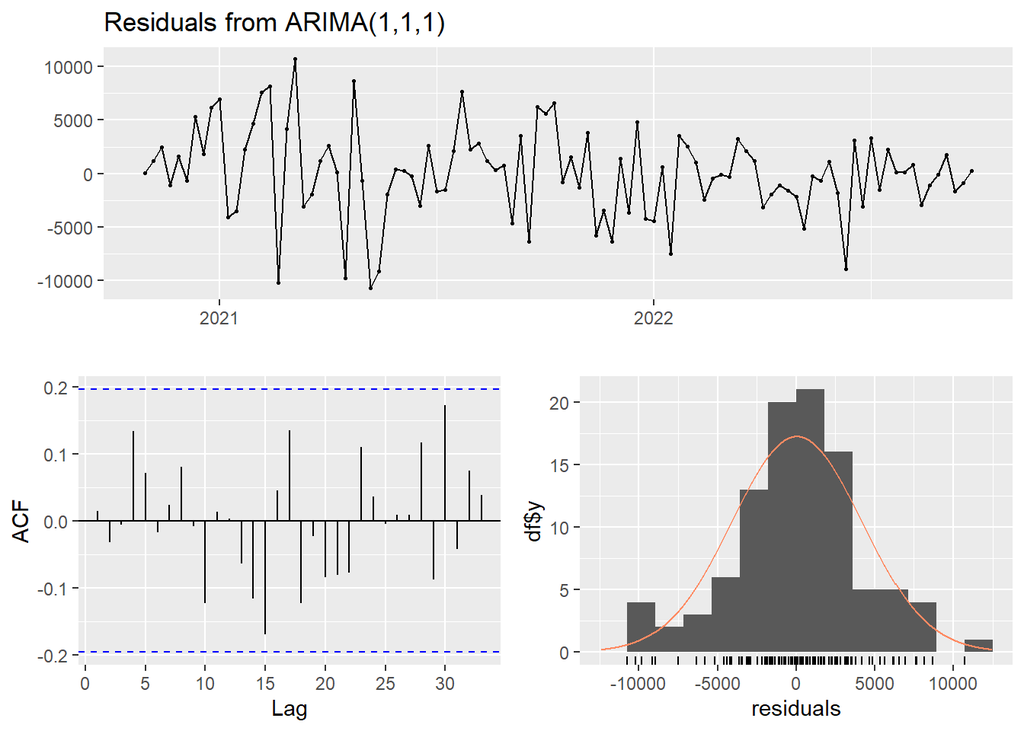

```
##
##  Ljung-Box test
##
## data:  Residuals from ARIMA(1,1,1)
## Q* = 16.015, df = 18, p-value = 0.5915
##
## Model df: 2.   Total lags used: 20
```

```r
# Analisis visual untuk ARIMA(1,1,1)
checkresiduals(model2)
```

**Interpretasi Visual:**

1. **Plot Sisaan vs Waktu (atas):** Sisaan tampak tersebar secara acak di sekitar garis nol tanpa adanya pola tren atau musiman. Hal ini menandakan model sudah baik dalam menangkap pola data.
2. **Plot ACF Sisaan (kiri bawah):** Tidak ada lag yang signifikan secara statistik (semua garis vertikal berada di dalam batas biru). Ini menunjukkan bahwa sisaan sudah saling bebas dan tidak memiliki autokorelasi.
3. **Histogram Sisaan (kanan bawah):** Distribusi sisaan terlihat mendekati sebaran normal (berbentuk lonceng) dan terpusat di sekitar nol.

Secara keseluruhan, visualisasi ini menunjukkan bahwa sisaan dari model **ARIMA(1,1,1)** telah memenuhi asumsi *white noise*, yang berarti model ini adalah model yang baik dan valid untuk data ini.

**Uji Formal**

**1) Uji Normalitas Sisaan (Shapiro-Wilk)**

- $H_0$: Sisaan menyebar normal.
- Kita berharap **p-value > 0.05**.

```r
shapiro.test(residuals(model2))
```

```
##
##  Shapiro-Wilk normality test
##
## data:  residuals(model2)
## W = 0.98305, p-value = 0.2279
```

Berdasarkan hasil uji Shapiro-Wilk, sisaan (residuals) dari model ini dapat dianggap **menyebar normal**.

Nilai **p-value = 0.2279**, yang jauh lebih besar dari tingkat signifikansi 0.05. Ini berarti kita **gagal menolak hipotesis nol** ($H_0$) yang menyatakan bahwa sisaan berdistribusi normal. Dengan demikian, asumsi normalitas untuk sisaan model ini **terpenuhi**.

**2) Uji Autokorelasi Sisaan (Ljung-Box)**

- $H_0$: Sisaan saling bebas (tidak ada autokorelasi).
- Kita berharap **p-value > 0.05**.

```r
# fitdf=2 karena model ARIMA(1,1,1) punya 2 parameter (p=1, q=1).
Box.test(residuals(model2), lag=10, type="Ljung-Box", fitdf=2)
```

```
##
##  Box-Ljung test
##
## data:  residuals(model2)
## X-squared = 5.1264, df = 8, p-value = 0.744
```

Berdasarkan hasil uji Ljung-Box, sisaan (residuals) dari model ini dapat dianggap **saling bebas (independen)** dan **tidak memiliki autokorelasi**.

Nilai **p-value = 0.744**, yang jauh lebih besar dari tingkat signifikansi 0.05. Ini berarti kita **gagal menolak hipotesis nol** ($H_0$) yang menyatakan bahwa sisaan tidak memiliki autokorelasi. Dengan demikian, asumsi sisaan yang bersifat *white noise* (acak) untuk model ini **terpenuhi**.

**3) Uji Homogenitas Ragam Sisaan (Ljung-Box pada Sisaan Kuadrat)**

- $H_0$: Ragam sisaan homogen.
- Kita berharap **p-value > 0.05**.

```r
squared_residuals_2 <- residuals(model2)^2
Box.test(squared_residuals_2, lag=10, type="Ljung-Box")
```

```
##
##  Box-Ljung test
##
## data:  squared_residuals_2
## X-squared = 33.76, df = 10, p-value = 0.0002028
```

Berdasarkan hasil uji Ljung-Box pada sisaan kuadrat, asumsi ragam sisaan yang **homogen tidak terpenuhi**.

Nilai **p-value = 0.0002028**, yang jauh lebih kecil dari tingkat signifikansi 0.05. Ini berarti kita **menolak hipotesis nol** ($H_0$) bahwa ragam sisaan bersifat homogen.

Hasil ini mengindikasikan adanya efek **heteroskedastisitas** (atau efek ARCH), di mana volatilitas (ragam) dari data tidak konstan sepanjang waktu, sama seperti yang ditemukan pada model ARIMA(0,1,0).

**4) Uji Nilai Tengah Sisaan (One-Sample t-test)**

- $H_0$: Nilai tengah (mean) sisaan sama dengan nol.
- Kita berharap **p-value > 0.05** untuk gagal menolak $H_0$.

```r
t.test(residuals(model2), mu = 0)
```

```
##
##  One Sample t-test
##
## data:  residuals(model2)
## t = 0.10111, df = 99, p-value = 0.9197
## alternative hypothesis: true mean is not equal to 0
## 95 percent confidence interval:
##  -780.074  863.847
## sample estimates:
## mean of x
##  41.88648
```

Berdasarkan hasil uji-t, **nilai tengah (mean) sisaan tidak berbeda nyata dari nol**.

Nilai **p-value = 0.9197**, yang jauh lebih besar dari tingkat signifikansi 0.05. Ini berarti kita **gagal menolak hipotesis nol** ($H_0$) bahwa rata-rata sisaan adalah nol. Dengan demikian, asumsi sisaan yang terpusat di nol untuk model ini **terpenuhi**.

### **Kesimpulan Uji Diagnostik**

Berdasarkan hasil uji diagnostik yang telah dilakukan, berikut adalah kesimpulan akhirnya.

Secara keseluruhan, **kedua model—ARIMA(0,1,0) dan ARIMA(1,1,1)—menunjukkan hasil diagnostik yang sangat mirip** dan keduanya dapat dianggap sebagai model yang valid, meskipun dengan satu catatan penting.

#### Ringkasan Hasil

- **Asumsi yang Terpenuhi** Kedua model berhasil **lolos** tiga dari empat asumsi krusial:
  1. **Normalitas:** Sisaan kedua model terdistribusi normal.
  2. **Tidak Ada Autokorelasi:** Sisaan kedua model bersifat independen dan acak (*white noise*).
  3. **Rataan Nol:** Sisaan kedua model terbukti memiliki rata-rata nol.

  Ini menunjukkan bahwa kedua model secara fundamental sudah baik dalam menangkap pola dalam data Anda.
- **Asumsi yang Tidak Terpenuhi* Satu-satunya asumsi yang **tidak terpenuhi** oleh kedua model adalah **homogenitas ragam**. Keduanya menunjukkan adanya efek **heteroskedastisitas** (atau efek ARCH), di mana volatilitas data tidak konstan. Ini adalah karakteristik yang **sangat umum ditemukan pada data keuangan** seperti harga Bitcoin, sehingga kegagalan pada uji ini dapat diterima untuk pemodelan ARIMA standar.

#### Penentuan Model Terbaik

Karena kedua model memiliki performa diagnostik yang nyaris identik, kita perlu kembali ke kriteria sebelumnya untuk menentukan pemenangnya:

1. **Prinsip Parsimoni (Kesederhanaan):** Model yang lebih sederhana selalu lebih diutamakan jika performanya setara. **ARIMA(0,1,0)** (tanpa parameter) jauh lebih sederhana daripada ARIMA(1,1,1) (dengan dua parameter).
2. **Kriteria Informasi (AICc & BIC):** Sebelumnya, nilai AICc dan BIC secara jelas menunjukkan bahwa **ARIMA(0,1,0)** adalah model yang lebih unggul.

Maka, model akhir yang terpilih adalah:
$$\textbf{ARIMA(0,1,0)}$$
Model ini adalah pilihan terbaik karena merupakan model paling sederhana yang mampu menjelaskan data dengan sangat baik (terbukti dari sisaannya yang lolos uji *white noise*) dan juga didukung oleh kriteria AICc/BIC.

## **9. Overfitting**

Tahap terakhir sebelum peramalan adalah memastikan model terbaik kita, **ARIMA(0,1,0)**, tidak *underfit*. Caranya adalah dengan menguji model yang sedikit lebih kompleks (model *overfit*) dan memeriksa apakah penambahan parameter tersebut memberikan peningkatan yang signifikan. Jika tidak, maka model kita yang lebih sederhana sudah tepat.

Kita akan memeriksa dua model yang lebih kompleks, yaitu **ARIMA(1,1,0)** dan **ARIMA(0,1,1)**, yang datanya sudah kita dapatkan dari analisis sebelumnya.

### **a. Memeriksa Model ARIMA(1,1,0)**

Dari hasil **Bagian 6 (Pendugaan Parameter)** dan **Bagian 7 (Ringkasan AIC)**, kita menemukan bahwa:

1. **Signifikansi Parameter:** Koefisien `ar1` pada model ARIMA(1,1,0) terbukti **tidak signifikan** secara statistik (p-value = 0.3221).
2. **Kriteria Informasi:** Nilai AICc-nya (1936.380) **lebih tinggi** daripada AICc model ARIMA(0,1,0) (1935.271).

**Kesimpulan:** Penambahan komponen AR(1) tidak memberikan kontribusi yang berarti dan justru memperburuk nilai AICc.

### **b. Memeriksa Model ARIMA(0,1,1)**

Sama seperti sebelumnya, dari hasil analisis kita menemukan bahwa:

1. **Signifikansi Parameter:** Koefisien `ma1` pada model ARIMA(0,1,1) juga **tidak signifikan** (p-value = 0.2592).
2. **Kriteria Informasi:** Nilai AICc-nya (1936.103) juga **lebih tinggi** daripada AICc model ARIMA(0,1,0).

**Kesimpulan:** Penambahan komponen MA(1) juga tidak meningkatkan kualitas model.

### **Kesimpulan Uji Overfitting️**

Karena penambahan satu parameter AR atau satu parameter MA menghasilkan model dengan parameter yang tidak signifikan dan nilai AICc yang lebih buruk, kita dapat menyimpulkan bahwa model **ARIMA(0,1,0)** bukanlah model yang *underfit*.

Model ini telah lolos uji *overfitting* dan dikonfirmasi sebagai model **terbaik yang paling parsimonious (sederhana dan efisien)** untuk data ini.

## **10. Model Terbaik: ARIMA(0,1,0)**

Setelah melalui seluruh tahapan identifikasi, pendugaan parameter, perbandingan kriteria informasi (AICc/BIC), uji diagnostik sisaan, dan uji *overfitting*, model terbaik dan paling tepat untuk data harga Bitcoin ini adalah **ARIMA(0,1,0)**.

Model ini terpilih berdasarkan tiga alasan utama yang saling menguatkan:

1. **Kriteria Informasi:** Model ARIMA(0,1,0) secara konsisten memiliki nilai **AICc dan BIC terendah**, menandakan bahwa ini adalah model yang paling efisien dalam menjelaskan data dengan kompleksitas minimal.
2. **Uji Diagnostik:** Sisaan dari model ini berhasil **lolos semua asumsi penting** (normalitas, tidak ada autokorelasi, dan rataan nol), membuktikan bahwa model ini valid dan mampu menangkap semua pola linier dalam data. Performanya setara dengan model yang lebih kompleks.
3. **Prinsip Parsimoni:** Model ini adalah model yang **paling sederhana (parsimonious)**. Uji *overfitting* mengonfirmasi bahwa penambahan parameter AR atau MA tidak memberikan peningkatan performa yang signifikan.

**Interpretasi Model**

Model ARIMA(0,1,0) dikenal juga sebagai model **Random Walk**. Ini memiliki interpretasi yang kuat dalam konteks data keuangan: perubahan harga dari satu periode ke periode berikutnya adalah acak dan tidak dapat diprediksi dari harga-harga sebelumnya. Dengan kata lain, prediksi terbaik untuk harga besok adalah harga hari ini.

Dengan demikian, model **ARIMA(0,1,0)** siap digunakan untuk tahap peramalan selanjutnya.

Berikut adalah perbaikan untuk Bagian 11.

## **11. Peramalan (Forecasting)**

Pada tahap akhir ini, kita akan menggunakan model terbaik yang telah terpilih, **ARIMA(0,1,0)**, untuk melakukan peramalan pada periode data *testing*. Kinerja peramalan kemudian akan dievaluasi dengan membandingkan hasil ramalan dengan data aktual pada periode tersebut.

### **a. Melakukan Peramalan**

Kita akan meramalkan data sebanyak panjang `test_data` ke depan menggunakan fungsi `forecast()`.

```r
# Melakukan peramalan menggunakan model terbaik (model1)
# h adalah horizon atau jumlah periode peramalan
forecast_result <- forecast(model1, h = length(test_data))

# Menampilkan hasil ramalan dalam bentuk tabel
print(forecast_result)
```

```
##          Point Forecast      Lo 80    Hi 80       Lo 95    Hi 95
## 2022.750        19311.9 13918.5610 24705.24  11063.4998 27560.30
## 2022.769        19311.9 11684.5669 26939.23   7646.9006 30976.90
## 2022.788        19311.9  9970.3629 28653.44   5025.2518 33598.55
## 2022.808        19311.9  8525.2221 30098.58   2815.0997 35808.70
## 2022.827        19311.9  7252.0274 31371.77    867.9165 37755.88
## 2022.846        19311.9  6100.9715 32522.83   -892.4716 39516.27
## 2022.865        19311.9  5042.4664 33581.33  -2511.3155 41135.12
## 2022.885        19311.9  4057.2338 34566.57  -4018.0987 42641.90
## 2022.904        19311.9  3131.8831 35491.92  -5433.3005 44057.10
## 2022.923        19311.9  2256.6647 36367.14  -6771.8316 45395.63
## 2022.942        19311.9  1424.2183 37199.58  -8044.9484 46668.75
## 2022.962        19311.9   628.8258 37994.97  -9261.3963 47885.20
## 2022.981        19311.9  -134.0602 38757.86 -10428.1297 49051.93
## 2023.000        19311.9  -868.1266 39491.93 -11550.7874 50174.59
## 2023.019        19311.9 -1576.4120 40200.21 -12634.0164 51257.82
## 2023.038        19311.9 -2261.4559 40885.26 -13681.7006 52305.50
## 2023.058        19311.9 -2925.4062 41549.21 -14697.1251 53320.93
## 2023.077        19311.9 -3570.0994 42193.90 -15683.0981 54306.90
## 2023.096        19311.9 -4197.1195 42820.92 -16642.0427 55265.84
## 2023.115        19311.9 -4807.8451 43431.65 -17576.0669 56199.87
## 2023.135        19311.9 -5403.4841 44027.28 -18487.0181 57110.82
## 2023.154        19311.9 -5985.1021 44608.90 -19376.5261 58000.33
## 2023.173        19311.9 -6553.6450 45177.45 -20246.0375 58869.84
## 2023.192        19311.9 -7109.9570 45733.76 -21096.8432 59720.64
## 2023.212        19311.9 -7654.7948 46278.59 -21930.1008 60553.90
## 2023.231        19311.9 -8188.8406 46812.64 -22746.8534 61370.65
```

### **b. Visualisasi Hasil Peramalan**

Visualisasi adalah cara terbaik untuk membandingkan nilai ramalan dengan data aktual secara intuitif.

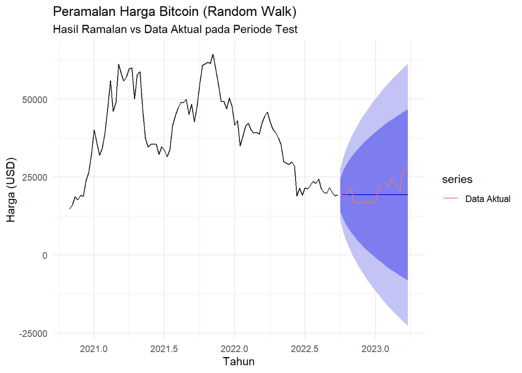

```r
# Plot hasil peramalan dan membandingkannya dengan data aktual
autoplot(forecast_result, main = "Peramalan Harga Bitcoin dengan ARIMA(0,1,0)") +
  autolayer(test_data, series = "Data Aktual") +
  theme_minimal() +
  labs(x = "Tahun", y = "Harga (USD)", title = "Peramalan Harga Bitcoin (Random Walk)",
       subtitle = "Hasil Ramalan vs Data Aktual pada Periode Test")
```

### **c. Evaluasi Akurasi Peramalan**

Untuk mengukur kinerja model secara kuantitatif, kita gunakan fungsi `accuracy()` untuk menghitung beberapa metrik kesalahan (*error metrics*).

```r
# Menghitung metrik akurasi dengan membandingkan ramalan dan data test
accuracy(forecast_result, test_data)
```

```
##                      ME     RMSE      MAE        MPE      MAPE      MASE
## Training set   44.98328 4187.350 3092.297 -0.3161549  8.198232 0.1696936
## Test set     1313.52692 3807.775 3090.412  3.6605213 14.238057 0.1695901
##                    ACF1 Theil's U
## Training set 0.09935743        NA
## Test set     0.75110950  1.739952
```

**Interpretasi Tabel Akurasi**

Secara ringkas, model Anda memiliki rata-rata kesalahan peramalan sekitar **14.2%** pada data baru (test set), dan performanya stabil karena tidak menunjukkan adanya *overfitting*.

**Ringkasan Kinerja Model**

Fokus utama kita adalah pada baris **“Test set”**, karena baris ini mengukur seberapa baik model melakukan peramalan pada data yang belum pernah dilihat sebelumnya.

- **MAPE (Mean Absolute Percentage Error): 14.2%** Ini adalah metrik yang paling mudah dipahami. Secara rata-rata, ramalan model Anda **menyimpang sekitar 14.2%** dari nilai aktualnya. Ini adalah ukuran kinerja utama dari peramalan Anda.
- **RMSE & MAE (Root Mean Squared Error & Mean Absolute Error)** Kedua metrik ini mengukur kesalahan dalam satuan asli data (USD). Rata-rata kesalahan absolut (MAE) pada `test set` adalah **$3,090**. Artinya, ramalan Anda rata-rata meleset sebesar nilai tersebut, bisa lebih tinggi atau lebih rendah dari nilai aktual.
- **ME (Mean Error): 1313.5** Nilai ME yang positif menunjukkan bahwa model Anda memiliki sedikit **kecenderungan untuk *under-forecast*** (nilai ramalan lebih rendah dari nilai aktual) selama periode pengujian.
- **Perbandingan Training vs. Test Set** Ukuran kesalahan pada `test set` (misalnya, MAE $3090) sangat mirip dengan `training set` (MAE $3092). Ini adalah pertanda yang **sangat baik**. Ini menunjukkan bahwa model Anda **stabil dan tidak *overfit***, karena kinerjanya tidak menurun drastis saat dihadapkan pada data baru.